# airplane_edit

## Airplane Satisfaction

dataset은 kaggle의 [Airline Passenger Satisfaction dataset](https://www.kaggle.com/teejmahal20/airline-passenger-satisfaction) 사용

아래는 Features 입니다.

```
    id
    Gender
    Customer Type
    Age
    Type of Travel
    Class
    Flight Distance
    Inflight wifi service
    Departure/Arrival time convenient
    Ease of Online booking
    Gate location
    Food and drink
    Online boarding
    Seat comfort
    Inflight entertainment
    On-board service
    Leg room service
    Baggage handling
    Checkin service
    Inflight service
    Cleanliness
    Departure Delay in Minutes
    Arrival Delay in Minutes
    satisfaction
```

## Satisfaction & Services

### Satisfaction 분포

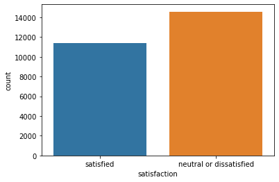

전체적으로 만족하지 않는 사람들의 수가 더 높은것을 알 수 있습니다. 어떤 서비스가 가장 불만족 스러웠을까요?

### Class별 만족/불만족

Class별로 살펴보았을 때, Eco Class가 상대적으로 불만족이, Business Class는 만족이 높게 나온것을 확인하실 수 있습니다.

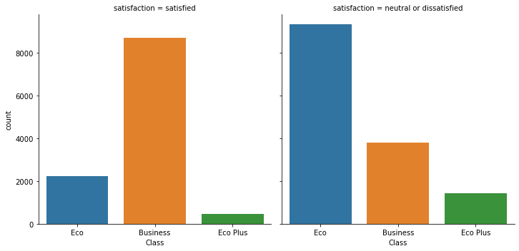

Class별로 살펴보았을 때, Eco Class가 상대적으로 불만족이, Business Class는 만족이 높게 나온것을 확인하실 수 있습니다.

#### 내부서비스 만족도

| Class | Food and drink | Seat comfort | Inflight entertainment | On-board service | Inflight service | Cleanliness |
| --- | --- | --- | --- | --- | --- | --- |
| Business | 3.356943 | 3.77503 | 3.654902 | 3.694678 | 3.852981 | 3.499480 |
| Eco | 3.087686 | 3.15384 | 3.089761 | 3.117088 | 3.476911 | 3.091577 |
| Eco Plus | 3.062598 | 3.10746 | 3.037559 | 2.991654 | 3.360981 | 3.070423 |

#### 외부서비스 만족도

| Class | Ease of Online booking | Gate location | Online boarding | Leg room service | Baggage handling | Checkin service |
| --- | --- | --- | --- | --- | --- | --- |
| Business | 2.922369 | 2.993758 | 3.728932 | 3.652181 | 3.852581 | 3.528291 |
| Eco | 2.593566 | 2.959962 | 2.821515 | 3.075925 | 3.450882 | 3.134210 |
| Eco Plus | 2.661972 | 2.971831 | 2.871153 | 3.035994 | 3.303599 | 3.004173 |

#### class별 내/외부 만족도 관계

class별로 각 서비스들의 만족도가 어떻게 차이 나는지 알아봅시다. (각 항목들의 만족도는 평균으로 나타내었습니다.)

**Business Class**

1.내부서비스의 만족도는 대체적으로 높은 것을 확인 할 수 있습니다.

2.Baggage handling(위탁수하물 서비스)과 Inflight service가 가장 만족도가 높은 것으로 나타났습니다.

**Eco Class**

1.Online boarding과 Ease of Online booking의 점수가 낮은것을 보아 해당 서비스가 불만족의 원인 중 하나로 추측됩니다.

2.Online boarding의 경우 Class간의 만족도 차이가 크게 나타나고 있습니다.

👇**공통적으로**👇

Ease of Online booking, Gate location의 평균이 class와 상관없이 낮은것을 확인할 수 있습니다.

따라서 온라인 예약의 어려움과 게이트 위치가 서비스 불만족에 큰 영향을 준다고 볼 수 있습니다.

### Satisfaction과 Type of Travel의 관계

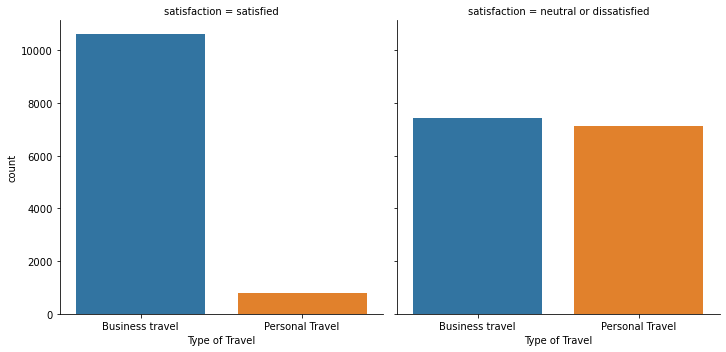

여행 목적별로 개인여행일 경우의 불만족이 크게 나타나는 것을 알 수 있습니다.

집에서 출발한 그 순간부터 여행이라고 인지하기때문에 비행기 서비스 또한 여행의 일부분으로 받아들여 기준이 더 엄격해지는게 아닌지 추측됩니다.

### Age와 Type of Travel

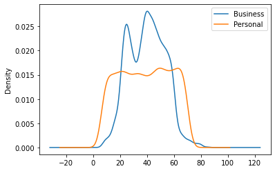

Business 목적인 탑승객과 Personal 목적인 탑승객의 연령차이가 뚜렷한 것을 볼 수 있습니다.

Business 목적인 탑승객은 직장인이 주라고 생각되는 만큼, 20~60대로 구성되어 있습니다.

Personal 목적인 탑승객들은 개인 여행인 만큼 가족단위 여행도 많을 것이고 다양한 사람들이 있는 만큼 연령대가 골고루 분포되어 있는 것을 확인할 수 있습니다.

### Age와 Class

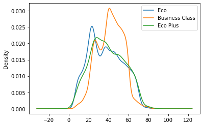

class별로 연령대가 차이나고 있으며, Eco와 Eco Plus class는 **20대에 크게 분포하고 있다는 점**이 눈에 띄며,

Business Class 경우에는 위의 **Business 목적의 탑승객의 분포와 비슷하다**는 것을 볼 수 있습니다.

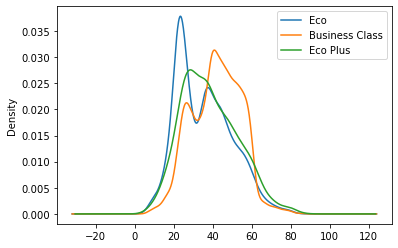